# Practical Statistics for Data Scientists

## Exploratory Data Analysis

This Notebook is the python equivalent of the R code for Chapter-1, from the book [Practical Statistics for Data Scientists](http://shop.oreilly.com/product/0636920048992.do) by Peter Bruce and Andrew Bruce. This [GitHub](https://github.com/andrewgbruce/statistics-for-data-scientists) repository has the complete R code for the book.

The authors note that the aim of the book is to be a "Desk Reference" for key Statistical concepts that are relevant to Data Science, explaining their importance and the reason behind that choice.

Data that is used in the book, has been curated by the authors and made available on [Google Drive](https://drive.google.com/drive/folders/0B98qpkK5EJemYnJ1ajA1ZVJwMzg) and [Dropbox](https://www.dropbox.com/sh/clb5aiswr7ar0ci/AABBNwTcTNey2ipoSw_kH5gra?dl=0)

```python
import numpy as np
import pandas as pd
import seaborn as sns
import matplotlib.pyplot as plt
```

```python
# Read the data from a .csv file
airlineDelaysDF = pd.read_csv("../data/dfw_airline.csv")
```

A variable is considered to be categorical, if each observation belongs to one of a set of distinct categories. Weather forecast describing cloud cover (with categories cloudy, partly cloudy, sunny) or a person's birth continent (with categories Africa, America, Antartica, Asia, Australia, Europe) are a couple of examples.

However, in certain applications, each observation is binary - that is having one of two possible outcomes.

Example: A person may

- accept or decline, an offer from a bank for a credit card
- opt-in or opt-out, of health insurance
- vote yes or no in a bond-election, to provide additional funds for city development

### BarPlot - Categorical Variables

```python
airlineDelaysDF.head(10)
```

|  | Carrier | ATC | Weather | Security | Inbound |
| --- | --- | --- | --- | --- | --- |
| 0 | 64263.16 | 84856.5 | 11235.42 | 343.15 | 118427.82 |

```python
headerList = []
headerList = list(airlineDelaysDF)
```

```python
flightDelays =[]
flightDelays = airlineDelaysDF.values.tolist()[0]
```

```python
myScale = 6 #change the scale of the flight delays
scaledFlightDelay = [i/myScale for i in flightDelays]
```

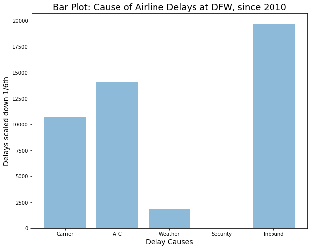

```python
y_pos = np.arange(len(headerList))

plt.figure(figsize=(10, 8))

plt.bar(y_pos, scaledFlightDelay, align='center', alpha=0.5)
plt.xticks(y_pos,headerList )
plt.xlabel('Delay Causes', fontsize=14)
plt.ylabel('Delays scaled down 1/6th', fontsize=14)
plt.title('Bar Plot: Cause of Airline Delays at DFW, since 2010', fontsize=18)

plt.show()
```

### NOTE

The Authors have briefly touched on **Mode** and **Expected Value** in the book.

If the distribution has a single mound or peak, the distribution is called unimodal, and the value that occurs most often is called the mode.

Expected value is the sum of values times their probability of occurrence, often used to sum up factor variable levels.